# Reproducible Data Cleaning in RMarkdown

EPID 7500 - Introduction to Coding in R for Public Health & the Life Sciences

Steve Bellan

August 28, 2017

## Load the necessary packages

Note that to enter a code segment we can do `Ctrl-Alt-i` (Windows) or `Cmd-Alt-i` (Mac)

```r
require(tidyverse)
```

## Knitting

- Use keyboard shortcuts to knit whenever you want
- `Ctrl-Shift-k` (Windows) or `Cmd-Shift-k` (Mac)

## Loading in a data set from the internet

- [WHO TB notification data provided by countries](http://www.who.int/tb/country/data/download/en/)
- Right click on `Download case notifications [1.9Mb]` and save it to your hard drive
- Cannot load directly from internet since no URL for the CSV file available
- [WHO Data Dictionary](https://extranet.who.int/tme/generateCSV.asp?ds=dictionary)

```r
notif <- read_csv('~/Downloads/TB_notifications_2017-08-27.csv')
```

```r
head(colnames(notif),20)
```

```
##  [1] "country"         "iso2"            "iso3"
##  [4] "iso_numeric"     "g_whoregion"     "year"
##  [7] "new_sp"          "new_sn"          "new_su"
## [10] "new_ep"          "new_oth"         "ret_rel"
## [13] "ret_taf"         "ret_tad"         "ret_oth"
## [16] "newret_oth"      "new_labconf"     "new_clindx"
## [19] "ret_rel_labconf" "ret_rel_clindx"
```

```r
notif[1:4,1:5]
```

```
## # A tibble: 4 x 5
##       country  iso2  iso3 iso_numeric g_whoregion
##         <chr> <chr> <chr>       <chr>       <chr>
## 1 Afghanistan    AF   AFG         004         EMR
## 2 Afghanistan    AF   AFG         004         EMR
## 3 Afghanistan    AF   AFG         004         EMR
## 4 Afghanistan    AF   AFG         004         EMR
```

## Workflow for running R code within Rmd

- I prefer to be able to use Console
- Set R output to console (not inline) when running lines [see here](https://support.rstudio.com/hc/en-us/community/posts/115000797947-Global-Changes-show-chunk-output-in-console-not-execute-all-lines)

## Select just a few variables of interest

```r
notif2 <- select(notif, iso3, country, g_whoregion, year, c_newinc) %>%
  rename(whoreg = g_whoregion, inc = c_newinc)
notif2
```

```
## # A tibble: 7,674 x 5
##     iso3     country whoreg  year   inc
##    <chr>       <chr>  <chr> <int> <int>
##  1   AFG Afghanistan    EMR  1980 71685
##  2   AFG Afghanistan    EMR  1981 71554
##  3   AFG Afghanistan    EMR  1982 41752
##  4   AFG Afghanistan    EMR  1983 52502
##  5   AFG Afghanistan    EMR  1984 18784
##  6   AFG Afghanistan    EMR  1985 10742
##  7   AFG Afghanistan    EMR  1986 14351
##  8   AFG Afghanistan    EMR  1987 18091
##  9   AFG Afghanistan    EMR  1988 16051
## 10   AFG Afghanistan    EMR  1989 14386
## # ... with 7,664 more rows
```

```r
head(distinct(notif2, country) %>% .$country)
```

```
## [1] "Afghanistan"    "Albania"        "Algeria"        "American Samoa"
## [5] "Andorra"        "Angola"
```

## Missing values

```r
indNA <- which(is.na(notif2$inc))
head(indNA)
```

```
## [1] 13 14 15 16 17 49
```

```r
slice(notif2, indNA)
```

```
## # A tibble: 534 x 5
##     iso3        country whoreg  year   inc
##    <chr>          <chr>  <chr> <int> <int>
##  1   AFG    Afghanistan    EMR  1992    NA
##  2   AFG    Afghanistan    EMR  1993    NA
##  3   AFG    Afghanistan    EMR  1994    NA
##  4   AFG    Afghanistan    EMR  1995    NA
##  5   AFG    Afghanistan    EMR  1996    NA
##  6   ALB        Albania    EUR  1992    NA
##  7   ALB        Albania    EUR  1993    NA
##  8   DZA        Algeria    AFR  1981    NA
##  9   ASM American Samoa    WPR  1995    NA
## 10   ASM American Samoa    WPR  2012    NA
## # ... with 524 more rows
```

- Excercise: Repeat this but look at rows with 0 values

```
## [1] 125 217 218 220 221 223
```

```
## # A tibble: 173 x 5
##     iso3        country whoreg  year   inc
##    <chr>          <chr>  <chr> <int> <int>
##  1   ASM American Samoa    WPR  1996     0
##  2   AIA       Anguilla    AMR  1980     0
##  3   AIA       Anguilla    AMR  1981     0
##  4   AIA       Anguilla    AMR  1983     0
##  5   AIA       Anguilla    AMR  1984     0
##  6   AIA       Anguilla    AMR  1986     0
##  7   AIA       Anguilla    AMR  1987     0
##  8   AIA       Anguilla    AMR  1988     0
##  9   AIA       Anguilla    AMR  1989     0
## 10   AIA       Anguilla    AMR  1990     0
## # ... with 163 more rows
```

## Identify countries without missing rows

- `sum(is.na(x))` tells you how many NAs are in x
- `sum(is.na(x))==0` tells you there are no NAs in x

```r
sum(is.na(c(0,NA,3,NA,5)))
```

```
## [1] 2
```

```r
fullcountry <-
  group_by(notif2, country) %>%
  summarize(noNAs = sum(is.na(inc))==0) %>%
  filter(noNAs==T) %>%
  .$country
head(fullcountry)
```

```
## [1] "Angola"     "Argentina"  "Armenia"    "Azerbaijan" "Bangladesh"
## [6] "Belarus"
```

## Subsetting

- Select the data set for which there are no NAs

```r
notif3 <- filter(notif2, country %in% fullcountry)
range(notif3$inc)
```

```
## [1]       0 1667136
```

```r
sum(is.na(notif3$inc))
```

```
## [1] 0
```

```r
glimpse(notif3)
```

```
## Observations: 3,988
## Variables: 5
## $ iso3    <chr> "AGO", "AGO", "AGO", "AGO", "AGO", "AGO", "AGO", "AGO"...
## $ country <chr> "Angola", "Angola", "Angola", "Angola", "Angola", "Ang...
## $ whoreg  <chr> "AFR", "AFR", "AFR", "AFR", "AFR", "AFR", "AFR", "AFR"...
## $ year    <int> 1980, 1981, 1982, 1983, 1984, 1985, 1986, 1987, 1988, ...
## $ inc     <int> 10117, 7501, 7911, 6625, 10153, 8653, 9363, 8510, 8184...
```

```r
summary(notif3)
```

```
##      iso3             country             whoreg               year
##  Length:3988        Length:3988        Length:3988        Min.   :1980
##  Class :character   Class :character   Class :character   1st Qu.:1989
##  Mode  :character   Mode  :character   Mode  :character   Median :1998
##                                                           Mean   :1998
##                                                           3rd Qu.:2007
##                                                           Max.   :2015
##       inc
##  Min.   :      0
##  1st Qu.:    624
##  Median :   3154
##  Mean   :  24714
##  3rd Qu.:  11465
##  Max.   :1667136
```

## Excercises

1. Write code that spreads `notif3` so that each country has it’s own column
2. Look at a boxplot of TB notifications by country for the 10 countries with the greatest # of notifications overall.
   - Hint: `group_by()` countries, then sum all notifications, then sort in descending order with `?arrange`

## Answers 1

1. Write code that spreads `notif3` so that each country has it’s own column

```
## function (data, key, value, fill = NA, convert = FALSE, drop = TRUE,
##     sep = NULL)
## NULL
```

```
## # A tibble: 6 x 5
##    iso3 country whoreg  year   inc
##   <chr>   <chr>  <chr> <int> <int>
## 1   AGO  Angola    AFR  1980 10117
## 2   AGO  Angola    AFR  1981  7501
## 3   AGO  Angola    AFR  1982  7911
## 4   AGO  Angola    AFR  1983  6625
## 5   AGO  Angola    AFR  1984 10153
## 6   AGO  Angola    AFR  1985  8653
```

```
## # A tibble: 5 x 5
##    year Angola Argentina Armenia Azerbaijan
##   <int>  <int>     <int>   <int>      <int>
## 1  1980  10117     16406     756       3080
## 2  1981   7501     16693     924       3180
## 3  1982   7911     17292     759       3217
## 4  1983   6625     17305     702       3176
## 5  1984  10153     16359     774       3506
```

```
## # A tibble: 36 x 5
##     iso3   country whoreg  year   inc
##    <chr>     <chr>  <chr> <int> <int>
##  1   ARG Argentina    AMR  1980 16406
##  2   ARG Argentina    AMR  1981 16693
##  3   ARG Argentina    AMR  1982 17292
##  4   ARG Argentina    AMR  1983 17305
##  5   ARG Argentina    AMR  1984 16359
##  6   ARG Argentina    AMR  1985 15987
##  7   ARG Argentina    AMR  1986 14681
##  8   ARG Argentina    AMR  1987 13368
##  9   ARG Argentina    AMR  1988 13267
## 10   ARG Argentina    AMR  1989 12636
## # ... with 26 more rows
```

## Answers 2

2. Look at a boxplot of TB notifications by country for the 10 countries with the greatest # of cumulative notifications across years.

```r
big_countries <-
  group_by(notif3, country) %>%
  summarize(cum_inc= sum(inc)) %>%
  arrange(desc(cum_inc)) %>%
  slice(1:10) %>%
  .$country
big_countries
```

```
##  [1] "India"                            "South Africa"
##  [3] "Philippines"                      "Russian Federation"
##  [5] "Bangladesh"                       "Viet Nam"
##  [7] "Democratic Republic of the Congo" "Myanmar"
##  [9] "Republic of Korea"                "Thailand"
```

## Answers 2

2. Look at a boxplot of TB notifications by country for the 10 countries with the greatest # of cumulative notifications across years.

```
##  [1] "India"                            "South Africa"
##  [3] "Philippines"                      "Russian Federation"
##  [5] "Bangladesh"                       "Viet Nam"
##  [7] "Democratic Republic of the Congo" "Myanmar"
##  [9] "Republic of Korea"                "Thailand"
```

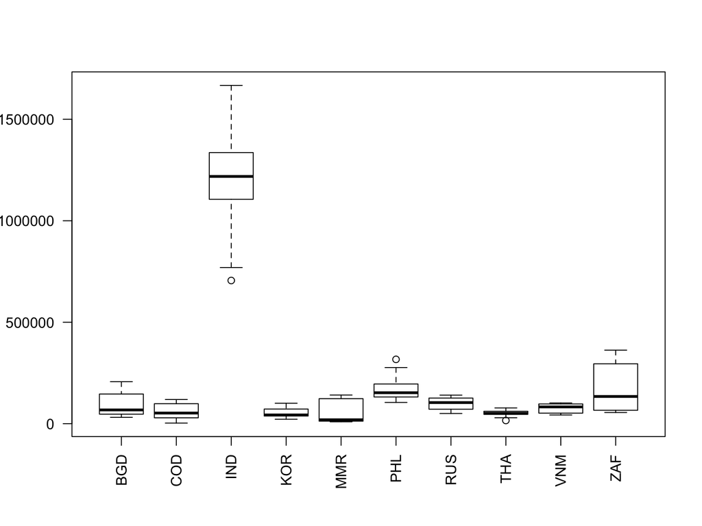

## Answers 2 (with ggplot)

2. Look at a boxplot of TB notifications by country for the 10 countries with the greatest # of cumulative notifications across years.

```
##  [1] "India"                            "South Africa"
##  [3] "Philippines"                      "Russian Federation"
##  [5] "Bangladesh"                       "Viet Nam"
##  [7] "Democratic Republic of the Congo" "Myanmar"
##  [9] "Republic of Korea"                "Thailand"
```

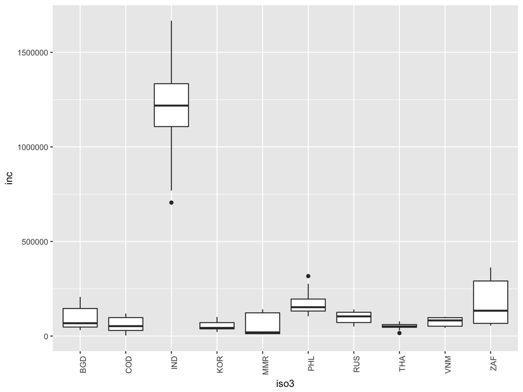

## Excercise 3

- [WHO Measles & Rubella Page](http://www.who.int/immunization/monitoring_surveillance/burden/vpd/surveillance_type/active/measles_monthlydata/en/)
- Download the [Distribution of measles cases by country and by month, 2011-2017](http://www.who.int/entity/immunization/monitoring_surveillance/burden/vpd/Table_407_Web_Number_Measles_Cases_Month_2017-08-09.xlsx?ua=1)
- Read it into R with the `xlsx` library (note you have to read 2nd sheet!)
- Reformat the data so it is in long with date in YYYY-MM format

## Answer 3

```r
require(readxl); require(tidyverse); require(lubridate); require(stringr)
getwd()
```

```
## [1] "/Users/stevenbellan/Documents/R Repos/EPID7500/Live Coding"
```

```r
meas <- read_xlsx('Table_407_Web_Number_Measles_Cases_Month_2017-08-09.xlsx', sheet = 2)
head(meas)
```

```
## # A tibble: 6 x 15
##    ISO3     Country  Year January February March April   May  June  July
##   <chr>       <chr> <dbl>   <chr>    <chr> <chr> <chr> <chr> <chr> <chr>
## 1   AFG Afghanistan  2011     138      145   211   229   157   144   102
## 2   AFG Afghanistan  2012     360      414   364   341   340   292   234
## 3   AFG Afghanistan  2013      36       51    47    69    59    58    51
## 4   AFG Afghanistan  2014      69       70    46    29    79    43    47
## 5   AFG Afghanistan  2015      89      160   269   198   208   116    65
## 6   AFG Afghanistan  2016       8       62    52    79    66    99    40
## # ... with 5 more variables: August <chr>, September <chr>, October <chr>,
## #   November <chr>, December <chr>
```

```r
?gather
meas2 <- gather(meas, month, cases, -c(ISO3, Country, Year) )
meas2$month <- factor(meas2$month, ordered = T, levels = month.name)
meas2$monthNum <- as.numeric(meas2$month)
meas2$monthNum <- str_pad(meas2$monthNum, width = 2, side = 'left', pad=0)
meas2
```

```
## # A tibble: 16,296 x 6
##     ISO3     Country  Year   month cases monthNum
##    <chr>       <chr> <dbl>   <ord> <chr>    <chr>
##  1   AFG Afghanistan  2011 January   138       01
##  2   AFG Afghanistan  2012 January   360       01
##  3   AFG Afghanistan  2013 January    36       01
##  4   AFG Afghanistan  2014 January    69       01
##  5   AFG Afghanistan  2015 January    89       01
##  6   AFG Afghanistan  2016 January     8       01
##  7   AFG Afghanistan  2017 January   207       01
##  8   AGO      Angola  2011 January    17       01
##  9   AGO      Angola  2012 January   373       01
## 10   AGO      Angola  2013 January   725       01
## # ... with 16,286 more rows
```

```r
distinct(meas2, month, monthNum)
```

```
## # A tibble: 12 x 2
##        month monthNum
##        <ord>    <chr>
##  1   January       01
##  2  February       02
##  3     March       03
##  4     April       04
##  5       May       05
##  6      June       06
##  7      July       07
##  8    August       08
##  9 September       09
## 10   October       10
## 11  November       11
## 12  December       12
```

```r
filter(meas2, monthNum==5)
```

```
## # A tibble: 0 x 6
## # ... with 6 variables: ISO3 <chr>, Country <chr>, Year <dbl>,
## #   month <ord>, cases <chr>, monthNum <chr>
```

```r
meas3 <-
  unite(meas2, ym, Year, monthNum, sep='-') %>%
  select(-month) %>%
  rename(date=ym)
meas3
```

```
## # A tibble: 16,296 x 4
##     ISO3     Country    date cases
##  * <chr>       <chr>   <chr> <chr>
##  1   AFG Afghanistan 2011-01   138
##  2   AFG Afghanistan 2012-01   360
##  3   AFG Afghanistan 2013-01    36
##  4   AFG Afghanistan 2014-01    69
##  5   AFG Afghanistan 2015-01    89
##  6   AFG Afghanistan 2016-01     8
##  7   AFG Afghanistan 2017-01   207
##  8   AGO      Angola 2011-01    17
##  9   AGO      Angola 2012-01   373
## 10   AGO      Angola 2013-01   725
## # ... with 16,286 more rows
```